# Netflix and Amazon Movies and TV Shows

## 1. Data Presentation

Each dataset contains 12 variables:

- **show_id** : corresponds to the unique ID of the movie or show
- **type**: indicates whether it is a movie or a TV show
- **title**: the title of the movie/show
- **director** : the production manager
- **cast**: the actors in the movie/show
- **country**: country in which the movie/show was produced
- **date_added**: date the movie/show was added on Netflix
- **release_year**: the actual release year of the movie/show
- **rating**: content rating (TV-MA, TV-14, TV-PG, R, PG-13, NR, TV-Y7, TV-G, TV-Y, TV-Y7-FV, G, UR, NC-17). To see the meaning of the different content ratings: https://fr.wikipedia.org/wiki/TV_Parental_Guidelines
- **duration**: for movies - length of the movie in minutes. For shows - number of seasons
- **listed_in**: the genre of the movie/show, the category.
- **description** : the description of the movie/show

## 2. Getting data

Data source: http://kaggle.com

- Netflix file: `netflix_titles.csv`
- Amazon file: `amazon_prime_titles.csv`

### 2.1 Import libraries

- `Counter` is useful for counting the occurrences of elements in a list, tuple, or other iterable. This can be helpful in various data analysis and processing tasks, such as calculating frequencies, identifying popular items, or analyzing the distribution of elements in a dataset.

```python
import pandas as pd
import numpy as np
import matplotlib.pyplot as plt
%matplotlib inline
import seaborn as sns
from collections import Counter
```

## 3. EDA Netflix

```python
netflix_df = pd.read_csv('netflix_titles.csv')
```

```python
netflix_df.head(2)
```

|  | show_id | type | title | director | cast | country | date_added | release_year | rating | duration | listed_in | description |
| --- | --- | --- | --- | --- | --- | --- | --- | --- | --- | --- | --- | --- |
| 0 | s1 | Movie | Dick Johnson Is Dead | Kirsten Johnson | NaN | United States | September 25, 2021 | 2020 | PG-13 | 90 min | Documentaries | As her father nears the end of his life, filmm... |
| 1 | s2 | TV Show | Blood & Water | NaN | Ama Qamata, Khosi Ngema, Gail Mabalane, Thaban... | South Africa | September 24, 2021 | 2021 | TV-MA | 2 Seasons | International TV Shows, TV Dramas, TV Mysteries | After crossing paths at a party, a Cape Town t... |

```python
netflix_df.shape
```

```
(8807, 12)
```

```python
netflix_df.info()
```

```
<class 'pandas.core.frame.DataFrame'>
RangeIndex: 8807 entries, 0 to 8806
Data columns (total 12 columns):
 #   Column        Non-Null Count  Dtype
---  ------        --------------  -----
 0   show_id       8807 non-null   object
 1   type          8807 non-null   object
 2   title         8807 non-null   object
 3   director      6173 non-null   object
 4   cast          7982 non-null   object
 5   country       7976 non-null   object
 6   date_added    8797 non-null   object
 7   release_year  8807 non-null   int64
 8   rating        8803 non-null   object
 9   duration      8804 non-null   object
 10  listed_in     8807 non-null   object
 11  description   8807 non-null   object
dtypes: int64(1), object(11)
memory usage: 825.8+ KB
```

```python
netflix_df.dtypes
```

```
show_id         object
type            object
title           object
director        object
cast            object
country         object
date_added      object
release_year     int64
rating          object
duration        object
listed_in       object
description     object
dtype: object
```

```python
# Count each type
netflix_df.dtypes.value_counts()
```

```
object    11
int64      1
dtype: int64
```

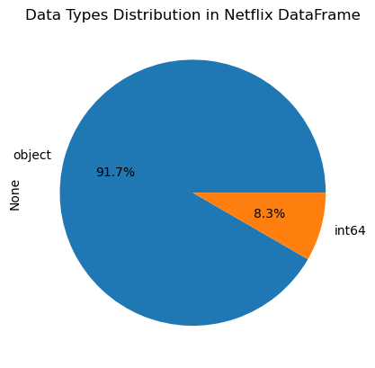

```python
# Set the plot style to a light theme
plt.style.use('default')
# Plot the pie chart with custom colors, labels, and title
colors = ['#1f77b4', '#ff7f0e', '#2ca02c']
netflix_df.dtypes.value_counts().plot.pie(colors=colors, autopct='%.1f%%', labels=netflix_df.dtypes.value_counts().index)
plt.title("Data Types Distribution in Netflix DataFrame")
plt.show()
```

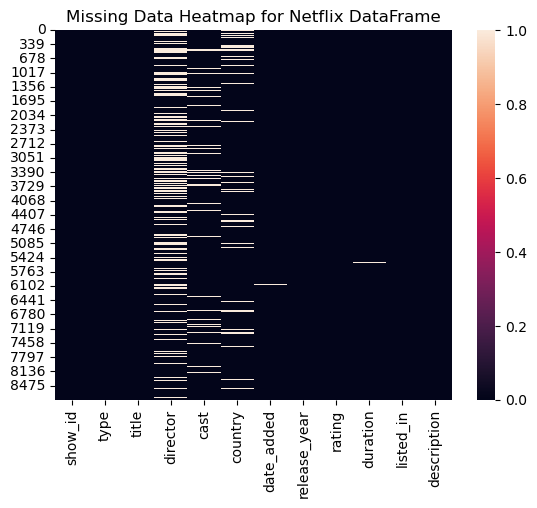

```python
# Checking missing data
sns.heatmap(netflix_df.isna())
plt.title("Missing Data Heatmap for Netflix DataFrame", fontsize=12)
plt.show()
```

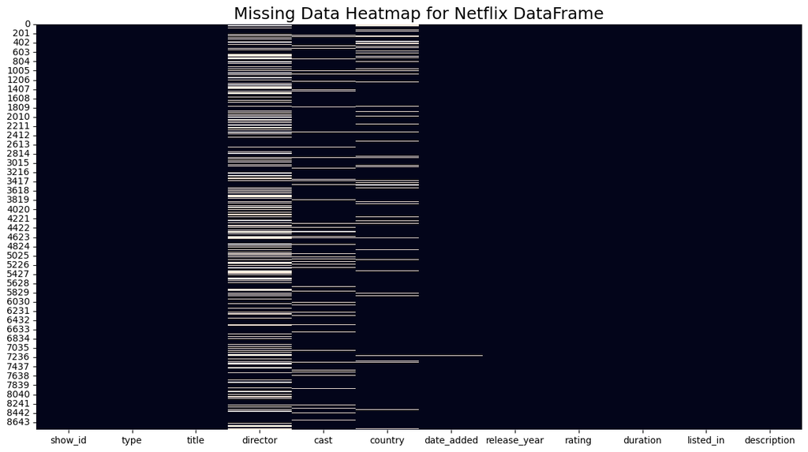

```python
# Remove the bar ==> cbar=False
plt.figure(figsize=(15,8))
sns.heatmap(netflix_df.isna(), cbar=False)
plt.title("Missing Data Heatmap for Netflix DataFrame", fontsize=18)
plt.show()
```

```python
# Percentage of missing values:

(netflix_df.isna().sum()/netflix_df.shape[0]).sort_values()*100
```

```
show_id          0.000000
type             0.000000
title            0.000000
release_year     0.000000
listed_in        0.000000
description      0.000000
duration         0.034064
rating           0.045418
date_added       0.113546
cast             9.367549
country          9.435676
director        29.908028
dtype: float64
```

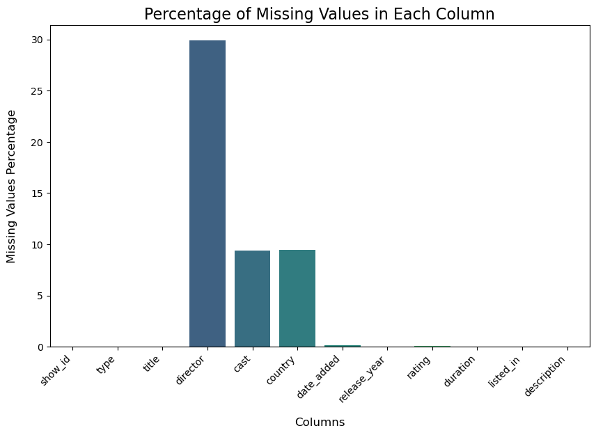

```python
# Calculate the missing values percentages
missing_percentages = (netflix_df.isna().sum() / netflix_df.shape[0]) * 100

# Create a countplot
plt.figure(figsize=(10, 6))
ax = sns.barplot(x=missing_percentages.index, y=missing_percentages.values, palette='viridis')

# sns.barplot(x=missing_percentages.index, y=missing_percentages.values, palette='viridis')
plt.xticks(rotation=45, ha='right')
plt.xlabel('Columns', labelpad=14, fontsize=12)
plt.ylabel('Missing Values Percentage', labelpad=14, fontsize=12)
plt.title('Percentage of Missing Values in Each Column', fontsize=16)

plt.show()
```

```python
netflix_df.describe(include='all')
```

|  | show_id | type | title | director | cast | country | date_added | release_year | rating | duration | listed_in | description |
| --- | --- | --- | --- | --- | --- | --- | --- | --- | --- | --- | --- | --- |
| count | 8807 | 8807 | 8807 | 6173 | 7982 | 7976 | 8797 | 8807.000000 | 8803 | 8804 | 8807 | 8807 |
| unique | 8807 | 2 | 8807 | 4528 | 7692 | 748 | 1767 | NaN | 17 | 220 | 514 | 8775 |
| top | s1 | Movie | Dick Johnson Is Dead | Rajiv Chilaka | David Attenborough | United States | January 1, 2020 | NaN | TV-MA | 1 Season | Dramas, International Movies | Paranormal activity at a lush, abandoned prope... |
| freq | 1 | 6131 | 1 | 19 | 19 | 2818 | 109 | NaN | 3207 | 1793 | 362 | 4 |
| mean | NaN | NaN | NaN | NaN | NaN | NaN | NaN | 2014.180198 | NaN | NaN | NaN | NaN |
| std | NaN | NaN | NaN | NaN | NaN | NaN | NaN | 8.819312 | NaN | NaN | NaN | NaN |
| min | NaN | NaN | NaN | NaN | NaN | NaN | NaN | 1925.000000 | NaN | NaN | NaN | NaN |
| 25% | NaN | NaN | NaN | NaN | NaN | NaN | NaN | 2013.000000 | NaN | NaN | NaN | NaN |
| 50% | NaN | NaN | NaN | NaN | NaN | NaN | NaN | 2017.000000 | NaN | NaN | NaN | NaN |
| 75% | NaN | NaN | NaN | NaN | NaN | NaN | NaN | 2019.000000 | NaN | NaN | NaN | NaN |
| max | NaN | NaN | NaN | NaN | NaN | NaN | NaN | 2021.000000 | NaN | NaN | NaN | NaN |

```python
duplicates = netflix_df[netflix_df.duplicated()]

print("Duplicate Rows:")
print(duplicates)
```

```
Duplicate Rows:
Empty DataFrame
Columns: [show_id, type, title, director, cast, country, date_added, release_year, rating, duration, listed_in, description]
Index: []
```

### 3.1 **Data manipulation**

#### 3.1.2 Changing date type

```python
netflix_df['date_added'] = pd.to_datetime(netflix_df['date_added'])
```

#### 3.1.3 Dropping unnecessary columns

```python
netflix_df.drop(['description'],axis = 1,inplace = True)
```

```python
netflix_df.head(2)
```

|  | show_id | type | title | director | cast | country | date_added | release_year | rating | duration | listed_in |
| --- | --- | --- | --- | --- | --- | --- | --- | --- | --- | --- | --- |
| 0 | s1 | Movie | Dick Johnson Is Dead | Kirsten Johnson | NaN | United States | 2021-09-25 | 2020 | PG-13 | 90 min | Documentaries |
| 1 | s2 | TV Show | Blood & Water | NaN | Ama Qamata, Khosi Ngema, Gail Mabalane, Thaban... | South Africa | 2021-09-24 | 2021 | TV-MA | 2 Seasons | International TV Shows, TV Dramas, TV Mysteries |

```python
netflix_df.isna().sum()
```

```
show_id            0
type               0
title              0
director        2634
cast             825
country          831
date_added        10
release_year       0
rating             4
duration           3
listed_in          0
dtype: int64
```

```python
# Dropping NaN rows
netflix_df.dropna(inplace = True)
```

```python
# NaN count
netflix_df.isna().sum()
```

```
show_id         0
type            0
title           0
director        0
cast            0
country         0
date_added      0
release_year    0
rating          0
duration        0
listed_in       0
dtype: int64
```

```python
netflix_df.shape
```

```
(5332, 11)
```

```python
netflix_df.dtypes
```

```
show_id                 object
type                    object
title                   object
director                object
cast                    object
country                 object
date_added      datetime64[ns]
release_year             int64
rating                  object
duration                object
listed_in               object
dtype: object
```

### 3.2 **Top Directors and Countries**

```python
directors = Counter(netflix_df.director)
```

```python
# The top 10 most common directors
topdirectors = directors.most_common(10)
```

- A bar chart displaying the top directors on the x-axis and the number of shows/movies they are associated with on the y-axis.
- Each bar's color will be indicative of the count of shows/movies for each director.

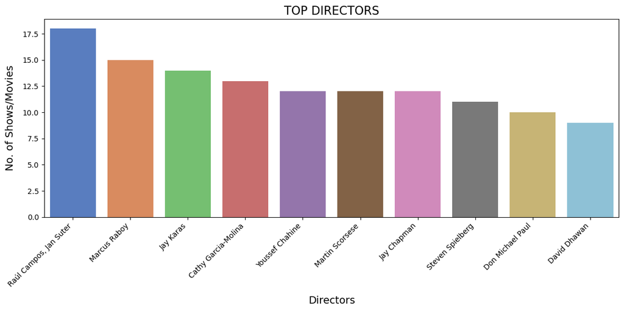

```python
# Convert the data to a DataFrame
data = pd.DataFrame(topdirectors, columns=['Directors', 'No. of Shows/Movies'])

# Plot
plt.figure(figsize=(12, 6))
sns.barplot(x='Directors', y='No. of Shows/Movies', data=data, palette='muted')

# Customize the plot
plt.title('TOP DIRECTORS', fontsize=16)
plt.xlabel('Directors', fontsize=14, labelpad=10)
plt.ylabel('No. of Shows/Movies', fontsize=14, labelpad=10)

# Rotate x-axis labels for better visibility
plt.xticks(rotation=45, ha='right')

plt.tight_layout()
plt.show()
```

```python
# The 'Counter' counts the occurrences of each country in the "country" column of the DataFrame.
countries = Counter(netflix_df.country)
```

```python
# Extract the top 10 most common countries
topcountries = countries.most_common(10)
topcountries
```

```
[('United States', 1846),
 ('India', 875),
 ('United Kingdom', 183),
 ('Canada', 107),
 ('Spain', 91),
 ('Egypt', 90),
 ('Nigeria', 88),
 ('Japan', 83),
 ('Turkey', 79),
 ('Indonesia', 76)]
```

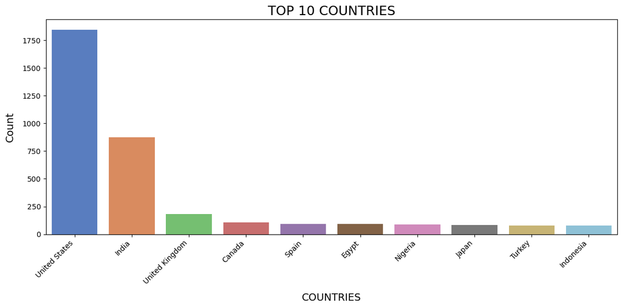

```python
# Convert the data to a DataFrame
data = pd.DataFrame(topcountries, columns=['Countries', 'Count'])

# Plot
plt.figure(figsize=(12, 6))
sns.barplot(x='Countries', y='Count', data=data, palette='muted')

# Customize the plot
plt.title('TOP 10 COUNTRIES', fontsize=18)
plt.xlabel('COUNTRIES', fontsize=14, labelpad=10)
plt.ylabel('Count', fontsize=14, labelpad=10)

# Rotate x-axis labels for better visibility
plt.xticks(rotation=45, ha='right')

plt.tight_layout()
plt.show()
```

### 3.3 **Top Cast**

```python
cast = Counter(netflix_df.cast)
```

```python
topcasts = cast.most_common(10)
topcasts
```

```
[('Samuel West', 10),
 ('Jeff Dunham', 7),
 ('Kevin Hart', 6),
 ('Bill Burr', 5),
 ('Jim Gaffigan', 5),
 ('Vir Das', 4),
 ('David Attenborough', 4),
 ('Jerry Seinfeld', 4),
 ('Tom Segura', 4),
 ('Iliza Shlesinger', 4)]
```

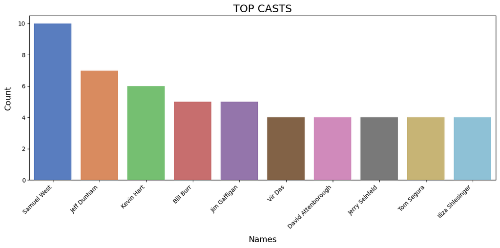

```python
# Convert the data to a DataFrame
data = pd.DataFrame(topcasts, columns=['Names', 'Count'])

# Plot
plt.figure(figsize=(12, 6))
sns.barplot(x='Names', y='Count', data=data, palette='muted')

# Customize the plot
plt.title('TOP CASTS', fontsize=18)
plt.xlabel('Names', fontsize=14, labelpad=10)
plt.ylabel('Count', fontsize=14, labelpad=10)

# Rotate x-axis labels for better visibility
plt.xticks(rotation=45, ha='right')

plt.tight_layout()
plt.show()
```

### 3. 4 **Top Years**

- `ryear` will be a Counter object that contains the count of movies or TV shows for each release year present in the "release_year" column of the DataFrame netflix_df

```python
ryear = Counter(netflix_df.release_year)
```

```python
# The top 10 most common release years and their counts
topry = ryear.most_common(10)
topry
```

```
[(2017, 657),
 (2018, 648),
 (2016, 577),
 (2019, 519),
 (2020, 442),
 (2015, 349),
 (2014, 242),
 (2013, 197),
 (2012, 163),
 (2021, 161)]
```

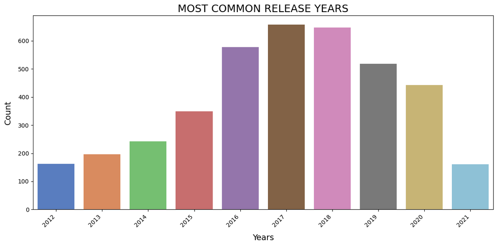

```python
# Convert the data to a DataFrame
data = pd.DataFrame(topry, columns=['Years', 'Count'])

# Plot
plt.figure(figsize=(12, 6))
sns.barplot(x='Years', y='Count', data=data, palette='muted')

# Customize the plot
plt.title('MOST COMMON RELEASE YEARS', fontsize=18)
plt.xlabel('Years', fontsize=14, labelpad=10)
plt.ylabel('Count', fontsize=14, labelpad=10)

# Rotate x-axis labels for better visibility
plt.xticks(rotation=45, ha='right')

plt.tight_layout()
plt.show()
```

### 3.5 **Top Movies Duration**

```python
# Select only the rows where the type is equal to 'Movie'
movies = netflix_df.type == 'Movie'
```

```python
# Count the occurrences of each unique value in the "duration" column for the rows corresponding to movies.
md = Counter(netflix_df[movies].duration)
```

```python
# The most common movie durations
# Gain insights into the typical length of movies available on Netflix.

topmd = md.most_common(10)
topmd
```

```
[('94 min', 135),
 ('93 min', 130),
 ('97 min', 129),
 ('95 min', 127),
 ('90 min', 123),
 ('91 min', 117),
 ('102 min', 112),
 ('96 min', 109),
 ('98 min', 109),
 ('92 min', 109)]
```

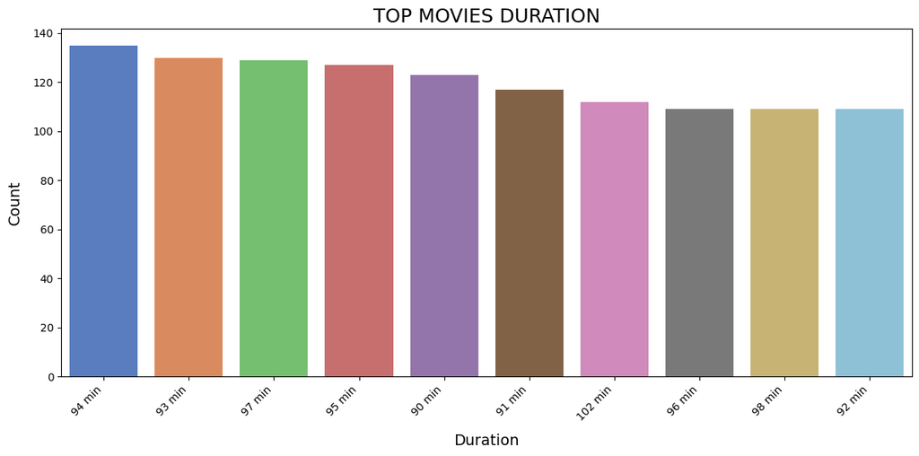

```python
# Convert the data to a DataFrame
data = pd.DataFrame(topmd, columns=['Duration', 'Count'])

# Plot
plt.figure(figsize=(12, 6))
sns.barplot(x='Duration', y='Count', data=data, palette='muted')

# Customize the plot
plt.title('TOP MOVIES DURATION', fontsize=18)
plt.xlabel('Duration', fontsize=14, labelpad=10)
plt.ylabel('Count', fontsize=14, labelpad=10)

# Rotate x-axis labels for better visibility
plt.xticks(rotation=45, ha='right')

plt.tight_layout()
plt.show()
```

### 3.6 **Top Shows Duration**

```python
# Select only the rows where the type is equal to 'TV Show'
shows = netflix_df.type == 'TV Show'
```

```python
# Count the occurrences of each unique value in the "duration" column for the rows corresponding to TV Show
sd = Counter(netflix_df[shows].duration)
```

```python
# The most common TV show durations
topsd = sd.most_common(10)
topsd
```

```
[('1 Season', 106),
 ('2 Seasons', 18),
 ('5 Seasons', 6),
 ('4 Seasons', 4),
 ('9 Seasons', 3),
 ('6 Seasons', 3),
 ('3 Seasons', 3),
 ('8 Seasons', 2),
 ('7 Seasons', 1),
 ('15 Seasons', 1)]
```

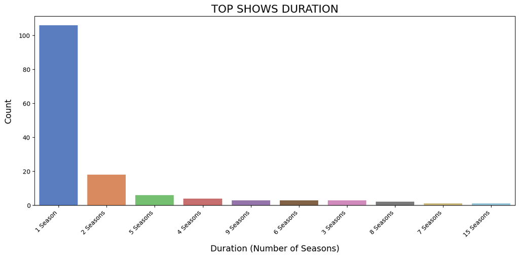

```python
# Convert the data to a DataFrame
data = pd.DataFrame(topsd, columns=['Seasons', 'Count'])

# Plot
plt.figure(figsize=(12, 6))
sns.barplot(x='Seasons', y='Count', data=data, palette='muted')

# Customize the plot
plt.title('TOP SHOWS DURATION',fontsize=18)
plt.xlabel('Duration (Number of Seasons)', fontsize=14, labelpad=10)
plt.ylabel('Count', fontsize=14, labelpad=10)

# Rotate x-axis labels for better visibility
plt.xticks(rotation=45, ha='right')

plt.tight_layout()
plt.show()
```

### 3.7 **TOP Genres**

```python
# Count the occurrences of each unique value in the "listed_in" column
tl = Counter(netflix_df.listed_in)
```

```python
# The top 10 most common genres or categories from the Counter tl above
topl = tl.most_common(10)
topl
```

```
[('Dramas, International Movies', 336),
 ('Stand-Up Comedy', 286),
 ('Comedies, Dramas, International Movies', 257),
 ('Dramas, Independent Movies, International Movies', 243),
 ('Children & Family Movies, Comedies', 179),
 ('Dramas, International Movies, Romantic Movies', 160),
 ('Documentaries', 156),
 ('Comedies, International Movies', 152),
 ('Comedies, International Movies, Romantic Movies', 143),
 ('Dramas', 133)]
```

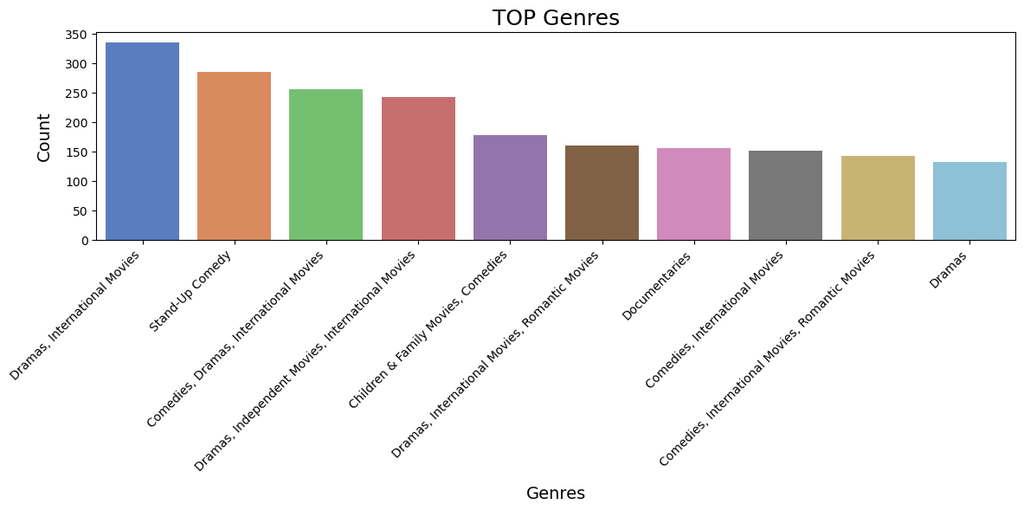

```python
# Convert the data to a DataFrame
data = pd.DataFrame(topl, columns=['Genres', 'Count'])

# Plot
plt.figure(figsize=(12, 6))
sns.barplot(x='Genres', y='Count', data=data, palette='muted')

# Customize the plot
plt.title('TOP Genres', fontsize=18)
plt.xlabel('Genres', fontsize=14, labelpad=10)
plt.ylabel('Count', fontsize=14, labelpad=10)

# Rotate x-axis labels for better visibility
plt.xticks(rotation=45, ha='right')

plt.tight_layout()
plt.show()
```

### 3.8 **Top Ratings**

```python
# Count the occurrences of each unique value in the "rating" column
tr = Counter(netflix_df.rating)
```

```python
# Get the top 10 most common ratings
topr = tr.most_common(10)
topr
```

```
[('TV-MA', 1822),
 ('TV-14', 1214),
 ('R', 778),
 ('PG-13', 470),
 ('TV-PG', 431),
 ('PG', 275),
 ('TV-G', 84),
 ('TV-Y7', 76),
 ('TV-Y', 76),
 ('NR', 58)]
```

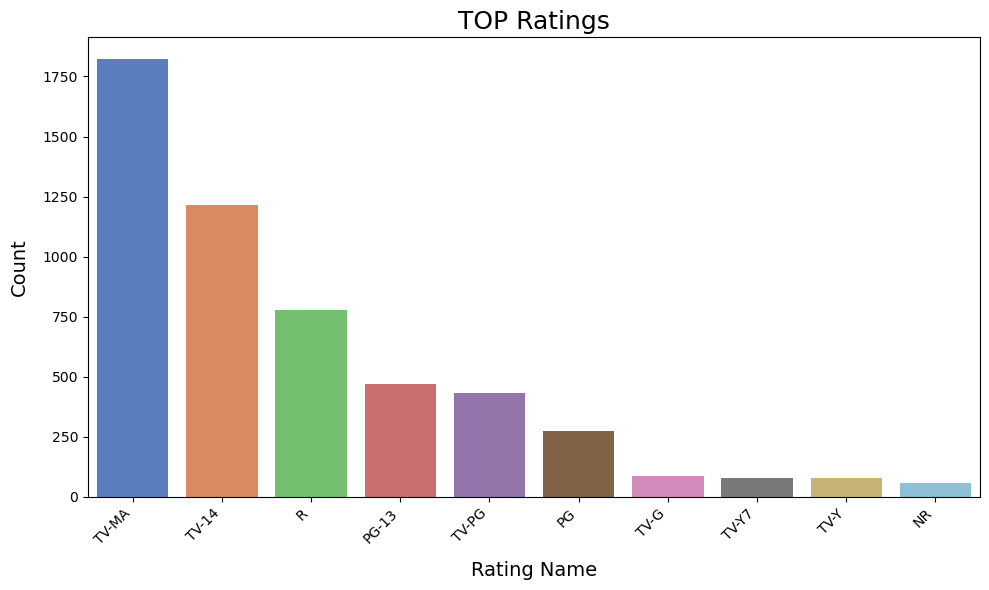

```python
# Convert the data to a DataFrame
data = pd.DataFrame(topr, columns=['Rating Name', 'Count'])

# Plot
plt.figure(figsize=(10, 6))
sns.barplot(x='Rating Name', y='Count', data=data, palette='muted')

# Customize the plot
plt.title('TOP Ratings',fontsize=18)
plt.xlabel('Rating Name', fontsize=14, labelpad=10)
plt.ylabel('Count', fontsize=14, labelpad=10)

# Rotate x-axis labels for better visibility
plt.xticks(rotation=45, ha='right')

plt.tight_layout()
plt.show()
```

## 4. EDA Amazon Prime

```python
amazon_df = pd.read_csv('amazon_prime_titles.csv')
```

```python
amazon_df.head(2)
```

|  | show_id | type | title | director | cast | country | date_added | release_year | rating | duration | listed_in | description |
| --- | --- | --- | --- | --- | --- | --- | --- | --- | --- | --- | --- | --- |
| 0 | s1 | Movie | The Grand Seduction | Don McKellar | Brendan Gleeson, Taylor Kitsch, Gordon Pinsent | Canada | March 30, 2021 | 2014 | NaN | 113 min | Comedy, Drama | A small fishing village must procure a local d... |
| 1 | s2 | Movie | Take Care Good Night | Girish Joshi | Mahesh Manjrekar, Abhay Mahajan, Sachin Khedekar | India | March 30, 2021 | 2018 | 13+ | 110 min | Drama, International | A Metro Family decides to fight a Cyber Crimin... |

```python
amazon_df.shape
```

```
(9668, 12)
```

```python
amazon_df.info()
```

```
<class 'pandas.core.frame.DataFrame'>
RangeIndex: 9668 entries, 0 to 9667
Data columns (total 12 columns):
 #   Column        Non-Null Count  Dtype
---  ------        --------------  -----
 0   show_id       9668 non-null   object
 1   type          9668 non-null   object
 2   title         9668 non-null   object
 3   director      7586 non-null   object
 4   cast          8435 non-null   object
 5   country       672 non-null    object
 6   date_added    155 non-null    object
 7   release_year  9668 non-null   int64
 8   rating        9331 non-null   object
 9   duration      9668 non-null   object
 10  listed_in     9668 non-null   object
 11  description   9668 non-null   object
dtypes: int64(1), object(11)
memory usage: 906.5+ KB
```

```python
amazon_df.dtypes
```

```
show_id         object
type            object
title           object
director        object
cast            object
country         object
date_added      object
release_year     int64
rating          object
duration        object
listed_in       object
description     object
dtype: object
```

```python
duplicates_prime = amazon_df[amazon_df.duplicated()]

print("Duplicate Rows:")
print(duplicates_prime)
```

```
Duplicate Rows:
Empty DataFrame
Columns: [show_id, type, title, director, cast, country, date_added, release_year, rating, duration, listed_in, description]
Index: []
```

```python
# Count each type
amazon_df.dtypes.value_counts()
```

```
object    11
int64      1
dtype: int64
```

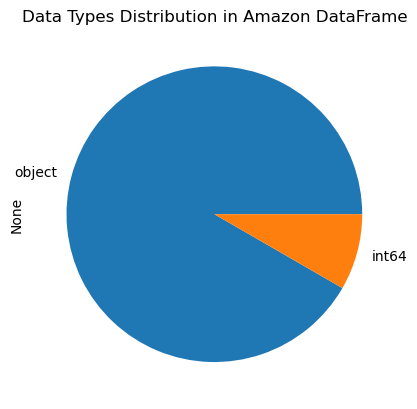

```python
# Type plot:

amazon_df.dtypes.value_counts().plot.pie()
plt.title("Data Types Distribution in Amazon DataFrame")
plt.show()
```

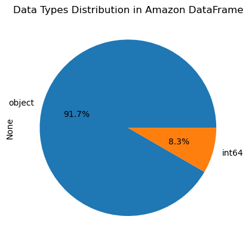

```python
# Set the plot style to a light theme
plt.style.use('default')

# Plot the pie chart with custom colors, labels, and title
colors = ['#1f77b4', '#ff7f0e', '#2ca02c']
amazon_df.dtypes.value_counts().plot.pie(colors=colors, autopct='%.1f%%', labels=amazon_df.dtypes.value_counts().index)
plt.title("Data Types Distribution in Amazon DataFrame")
plt.show()
```

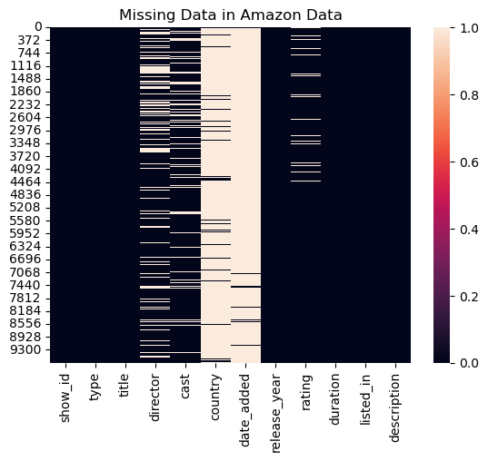

```python
# Checking missing values
sns.heatmap(amazon_df.isna())
plt.title('Missing Data in Amazon Data')
plt.show()
```

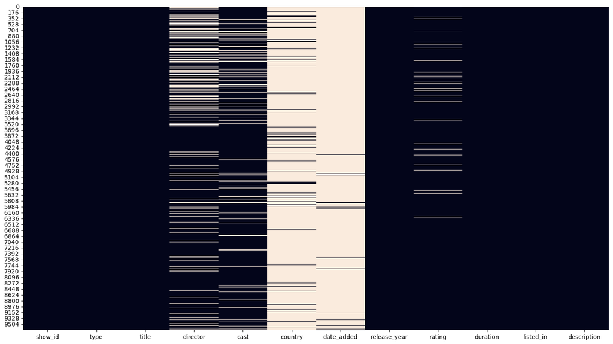

```python
# remove the bar ==> cbar=False
plt.figure(figsize=(18,10))
sns.heatmap(amazon_df.isna(), cbar=False)
plt.show()
```

```python
# Percentage of missing values:
# dividing by rows and sort in ascending order

(amazon_df.isna().sum()/amazon_df.shape[0]).sort_values()*100
```

```
show_id          0.000000
type             0.000000
title            0.000000
release_year     0.000000
duration         0.000000
listed_in        0.000000
description      0.000000
rating           3.485726
cast            12.753413
director        21.534961
country         93.049235
date_added      98.396773
dtype: float64
```

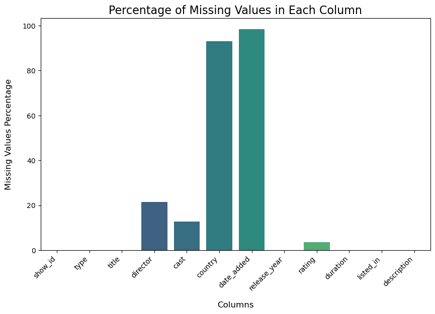

```python
# Calculate the missing values percentages
missing_percentages = (amazon_df.isna().sum() / amazon_df.shape[0]) * 100

# Create a countplot
plt.figure(figsize=(10, 6))
ax = sns.barplot(x=missing_percentages.index, y=missing_percentages.values, palette='viridis')

# sns.barplot(x=missing_percentages.index, y=missing_percentages.values, palette='viridis')
plt.xticks(rotation=45, ha='right')
plt.xlabel('Columns', labelpad=14, fontsize=12)
plt.ylabel('Missing Values Percentage', labelpad=14, fontsize=12)
plt.title('Percentage of Missing Values in Each Column', fontsize=16)

plt.show()
```

```python
amazon_df.describe(include='all')
```

|  | show_id | type | title | director | cast | country | date_added | release_year | rating | duration | listed_in | description |
| --- | --- | --- | --- | --- | --- | --- | --- | --- | --- | --- | --- | --- |
| count | 9668 | 9668 | 9668 | 7586 | 8435 | 672 | 155 | 9668.000000 | 9331 | 9668 | 9668 | 9668 |
| unique | 9668 | 2 | 9668 | 5774 | 7927 | 86 | 84 | NaN | 24 | 219 | 518 | 9414 |
| top | s1 | Movie | The Grand Seduction | Mark Knight | Maggie Binkley | United States | March 30, 2021 | NaN | 13+ | 1 Season | Drama | Arpo was designed as a commando robot, built a... |
| freq | 1 | 7814 | 1 | 113 | 56 | 253 | 14 | NaN | 2117 | 1342 | 986 | 15 |
| mean | NaN | NaN | NaN | NaN | NaN | NaN | NaN | 2008.341849 | NaN | NaN | NaN | NaN |
| std | NaN | NaN | NaN | NaN | NaN | NaN | NaN | 18.922482 | NaN | NaN | NaN | NaN |
| min | NaN | NaN | NaN | NaN | NaN | NaN | NaN | 1920.000000 | NaN | NaN | NaN | NaN |
| 25% | NaN | NaN | NaN | NaN | NaN | NaN | NaN | 2007.000000 | NaN | NaN | NaN | NaN |
| 50% | NaN | NaN | NaN | NaN | NaN | NaN | NaN | 2016.000000 | NaN | NaN | NaN | NaN |
| 75% | NaN | NaN | NaN | NaN | NaN | NaN | NaN | 2019.000000 | NaN | NaN | NaN | NaN |
| max | NaN | NaN | NaN | NaN | NaN | NaN | NaN | 2021.000000 | NaN | NaN | NaN | NaN |

### 4.1 **Data Manipulation**

#### 4.1.2 Changing date type

```python
amazon_df['date_added'] = pd.to_datetime(amazon_df['date_added'])
```

#### 4.1.3 Dropping unnecessary columns

```python
# Remove useless cols:
amazon_df.drop(['description'],axis = 1,inplace = True)
```

```python
amazon_df.head(2)
```

|  | show_id | type | title | director | cast | country | date_added | release_year | rating | duration | listed_in |
| --- | --- | --- | --- | --- | --- | --- | --- | --- | --- | --- | --- |
| 0 | s1 | Movie | The Grand Seduction | Don McKellar | Brendan Gleeson, Taylor Kitsch, Gordon Pinsent | Canada | 2021-03-30 | 2014 | NaN | 113 min | Comedy, Drama |
| 1 | s2 | Movie | Take Care Good Night | Girish Joshi | Mahesh Manjrekar, Abhay Mahajan, Sachin Khedekar | India | 2021-03-30 | 2018 | 13+ | 110 min | Drama, International |

```python
amazon_df.isna().sum()
```

```
show_id            0
type               0
title              0
director        2082
cast            1233
country         8996
date_added      9513
release_year       0
rating           337
duration           0
listed_in          0
dtype: int64
```

```python
amazon_df.shape
```

```
(9668, 11)
```

```python
#Dropping NAN rows
#amazon_df.dropna(inplace = True)
```

```python
# Replace NaN with 'Unknown' in the 'director' column
amazon_df['director'] = amazon_df['director'].fillna('Unknown')
```

```python
amazon_df['director'] = amazon_df['director'].replace('1', 'unknown')
```

```python
# Replace NaN with 'Unknown' in the 'country' column
#amazon_df['country'] = amazon_df['country'].fillna('Unknown')
```

```python
# NaN count
amazon_df.isna().sum()
```

```
show_id            0
type               0
title              0
director           0
cast            1233
country         8996
date_added      9513
release_year       0
rating           337
duration           0
listed_in          0
dtype: int64
```

```python
amazon_df.shape
```

```
(9668, 11)
```

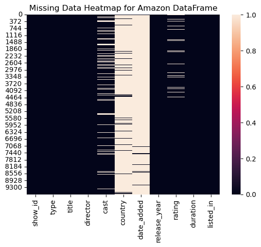

```python
sns.heatmap(amazon_df.isna())
plt.title("Missing Data Heatmap for Amazon DataFrame")
plt.show()
```

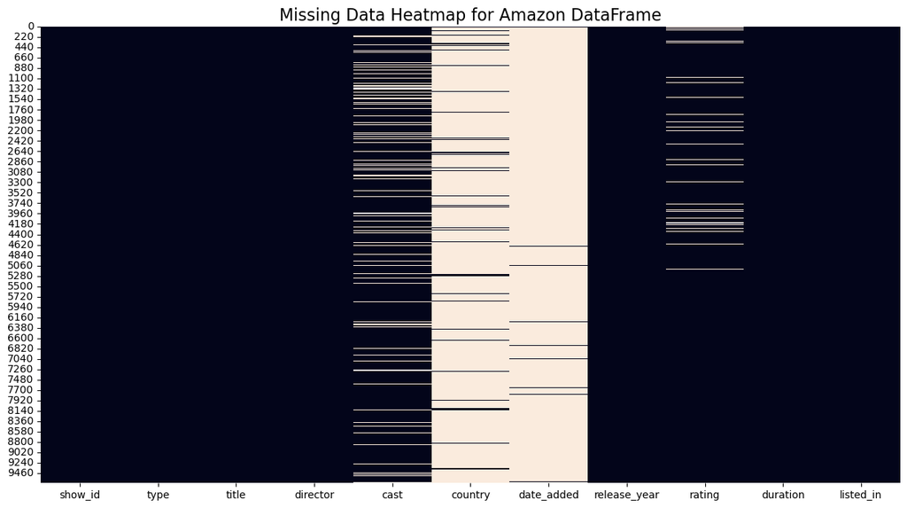

```python
# To remove the bar ==> cbar=False
plt.figure(figsize=(15,8))
sns.heatmap(amazon_df.isna(), cbar=False)
plt.title("Missing Data Heatmap for Amazon DataFrame", fontsize=16)
plt.show()
```

### 4.2 **Top Directors and Countries**

```python
# This information can be used to identify the most prolific directors on Amazon Prime
# Get the frequency distribution of directors in the df
adirectors = Counter(amazon_df.director)
```

```python
# The top 10 most common directors in the Amazon dataset
atopdirectors = adirectors.most_common(10)
atopdirectors
```

```
[('Unknown', 2082),
 ('Mark Knight', 113),
 ('Cannis Holder', 61),
 ('Moonbug Entertainment', 37),
 ('Jay Chapman', 34),
 ('Arthur van Merwijk', 30),
 ('Manny Rodriguez', 22),
 ('John English', 20),
 ('unknown', 16),
 ('Brian Volk-Weiss', 15)]
```

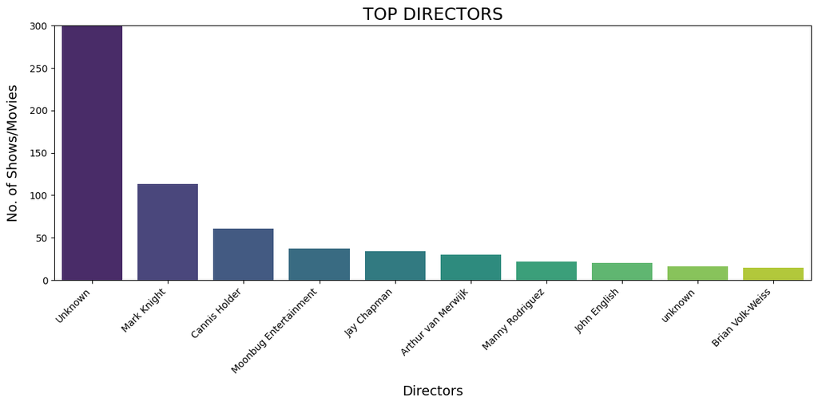

```python
# Convert the data to a DataFrame
data = pd.DataFrame(atopdirectors, columns=['Directors', 'No. of Shows/Movies'])

# Plotting the bar plot
plt.figure(figsize=(12, 6))
sns.barplot(x='Directors', y='No. of Shows/Movies', data=data, palette='viridis')

# Customize the plot
plt.title('TOP DIRECTORS', fontsize=18)
plt.xlabel('Directors',fontsize=14, labelpad=10)
plt.ylabel('No. of Shows/Movies', fontsize=14, labelpad=10)
plt.xticks(rotation=45, ha='right')
plt.ylim(0, 300)

plt.tight_layout()
plt.show()
```

```python
# Count the occurrences of each unique country in the df.
acountry = Counter(amazon_df.country)
```

```python
# The top 10 most common countries in the df
atopcountry = acountry.most_common(10)
atopcountry
```

```
[(nan, 8996),
 ('United States', 253),
 ('India', 229),
 ('United Kingdom', 28),
 ('Canada', 16),
 ('United Kingdom, United States', 12),
 ('Spain', 8),
 ('Italy', 8),
 ('Canada, United States', 7),
 ('United States, United Kingdom', 6)]
```

The following bar chart will display the top countries with the most content available on Amazon Prime, and the height of each bar represents the number of movies or TV shows from that country.

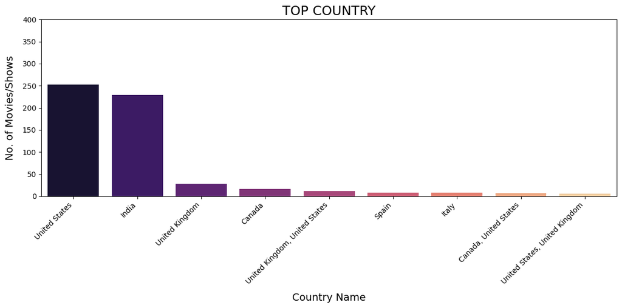

```python
# SEABORN
# Convert the data to a DataFrame
data = pd.DataFrame(atopcountry, columns=['Country Name', 'No. of Movies/Shows'])

# Plot
plt.figure(figsize=(12, 6))
sns.barplot(x='Country Name', y='No. of Movies/Shows', data=data, palette='magma')

# Customize the plot
plt.title('TOP COUNTRY', fontsize=18)
plt.xlabel('Country Name',fontsize=14, labelpad=10)
plt.ylabel('No. of Movies/Shows', fontsize=14, labelpad=10)
plt.xticks(rotation=45, ha='right')
plt.ylim(0, 400)

plt.tight_layout()
plt.show()
```

### 4.3 **Top Cast**

```python
# Replace '1' with an empty string in the 'cast' column
amazon_df['cast'] = amazon_df['cast'].replace('1', 'unknown')
```

```python
# Count how many times each cast member appears in the cast column
acast = Counter(amazon_df.cast)
```

```python
# The top 10 most common cast members in the df
atopcast = acast.most_common(10)
atopcast
```

```
[(nan, 1233),
 ('Maggie Binkley', 56),
 ('unknown', 34),
 ('Anne-Marie Newland', 24),
 ('Cassandra Peterson', 21),
 ('Grace Tamayo, Erin Webbs', 17),
 ('Gene Autry, Champion, Gail Davis', 12),
 ('Stevin John', 11),
 ('LB, Aaron Michael', 9),
 ('Gallagher', 9)]
```

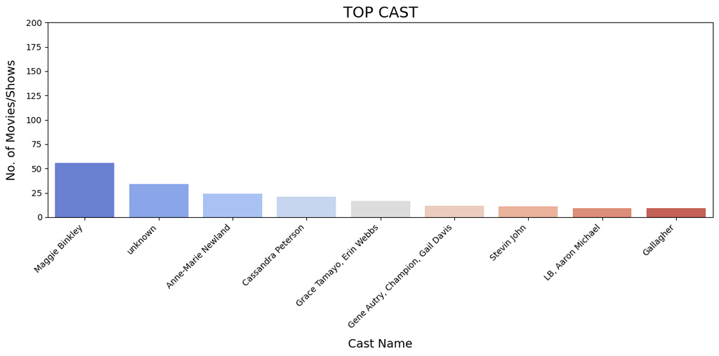

```python
# SEABORN
# Convert the data to a DataFrame
data = pd.DataFrame(atopcast, columns=['Name of Cast', 'No. of Movies/Shows'])

# Plot the bar
plt.figure(figsize=(12, 6))
sns.barplot(x='Name of Cast', y='No. of Movies/Shows', data=data, palette='coolwarm')

# Customize the plot
plt.title('TOP CAST', fontsize=18)
plt.xlabel('Cast Name', fontsize=14, labelpad=10)
plt.ylabel('No. of Movies/Shows', fontsize=14, labelpad=10)
plt.xticks(rotation=45, ha='right')
plt.ylim(0, 200)

plt.tight_layout()
plt.show()
```

### 4.4 **Top Year**

- This information allows us to analyze the distribution of content based on release years on Amazon Prime, identifying which years have more content and potential trends or patterns over time.

```python
# Count the occurrences of each unique release year in the dataset
ayear = Counter(amazon_df.release_year)
```

```python
# The top 8 most common release years in the  dataset along with their respective counts
toprya = ayear.most_common(8)
toprya
```

```
[(2021, 1442),
 (2020, 962),
 (2019, 929),
 (2018, 623),
 (2017, 562),
 (2016, 521),
 (2014, 391),
 (2015, 378)]
```

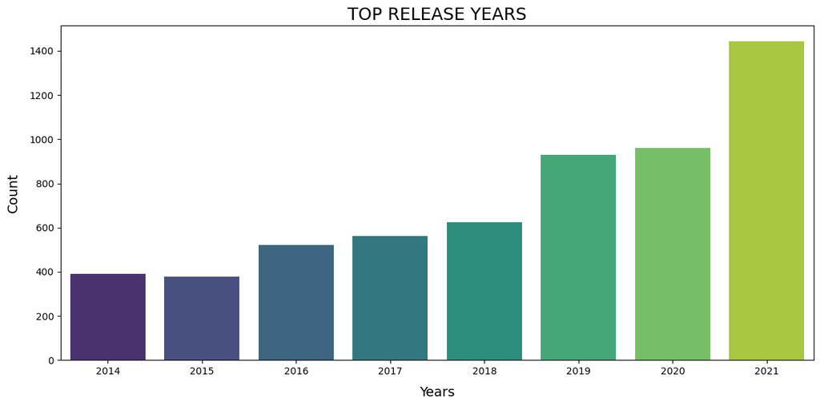

```python
#SEABORN
# Convert the data to a DataFrame
data = pd.DataFrame(toprya, columns=['Years', 'Count'])

# Plot the bar
plt.figure(figsize=(12, 6))
sns.barplot(x='Years', y='Count', data=data, palette='viridis')

# Customize the plot
plt.title('TOP RELEASE YEARS', fontsize=18)
plt.xlabel('Years', fontsize=14, labelpad=10)
plt.ylabel('Count', fontsize=14, labelpad=10)

plt.tight_layout()
plt.show()
```

### 4.5 **Top Movies Duration**

```python
# Get movies only
amovies = amazon_df.type == 'Movie'
```

```python
# Frequency distribution of the movie durations
amovies = Counter(amazon_df[amovies].duration)
```

```python
# The most common movie durations in the df
topmovies = amovies.most_common(10)
```

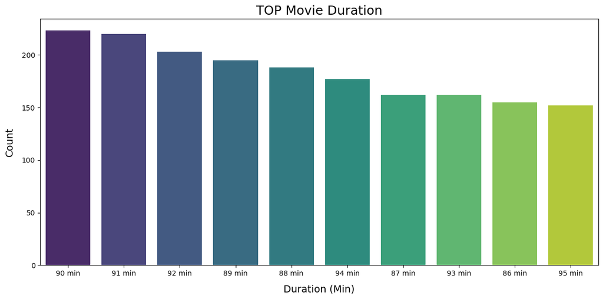

```python
# SEABORN
# Convert the data to a DataFrame
data = pd.DataFrame(topmovies, columns=['Duration(Min)', 'Count'])

# Plot the bar
plt.figure(figsize=(12, 6))
sns.barplot(x='Duration(Min)', y='Count', data=data, palette='viridis')

# Customize the plot
plt.title('TOP Movie Duration', size=18)
plt.xlabel('Duration (Min)', fontsize=14, labelpad=10)
plt.ylabel('Count', fontsize=14, labelpad=10)

plt.tight_layout()
plt.show()
```

### 4.6 **Top Shows Duration**

```python
# Select the rows where the type is equal to 'TV Show'
ashows = amazon_df.type == 'TV Show'
ashows
```

```
0       False
1       False
2       False
3       False
4       False
        ...
9663    False
9664     True
9665    False
9666     True
9667    False
Name: type, Length: 9668, dtype: bool
```

```python
# Count the occurrences of each unique value in the "duration" column for the rows corresponding to TV Show
ashows = Counter(amazon_df[ashows].duration)
ashows
```

```
Counter({'1 Season': 1342,
         '3 Seasons': 110,
         '2 Seasons': 229,
         '4 Seasons': 62,
         '7 Seasons': 15,
         '9 Seasons': 6,
         '6 Seasons': 23,
         '5 Seasons': 39,
         '29 Seasons': 1,
         '19 Seasons': 1,
         '21 Seasons': 1,
         '8 Seasons': 10,
         '12 Seasons': 3,
         '11 Seasons': 3,
         '10 Seasons': 5,
         '14 Seasons': 3,
         '15 Seasons': 1})
```

```python
# The most common TV show durations in the df
atopshows = ashows.most_common(8)
atopshows
```

```
[('1 Season', 1342),
 ('2 Seasons', 229),
 ('3 Seasons', 110),
 ('4 Seasons', 62),
 ('5 Seasons', 39),
 ('6 Seasons', 23),
 ('7 Seasons', 15),
 ('8 Seasons', 10)]
```

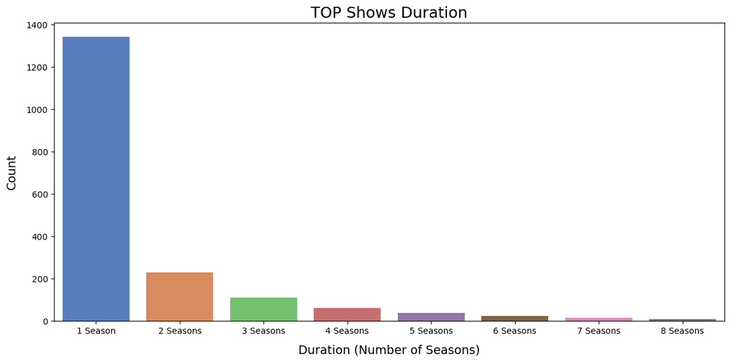

```python
# Convert the data to a DataFrame
data = pd.DataFrame(atopshows, columns=['Duration', 'Count'])

# Plot
plt.figure(figsize=(12, 6))
sns.barplot(x='Duration', y='Count', data=data, palette='muted')

# Customize the plot
plt.title('TOP Shows Duration', fontsize=18)
plt.xlabel('Duration (Number of Seasons)', fontsize=14, labelpad=10)
plt.ylabel('Count', fontsize=14, labelpad=10)

plt.tight_layout()
plt.show()
```

### 4.7 **Top Genres**

```python
# Count the occurrences of each unique value in the "listed_in" column
atl = Counter(amazon_df.listed_in)
```

```python
# The 10 most common genres and their respective counts in the Amazon Prime dataset
atopl = atl.most_common(10)
atopl
```

```
[('Drama', 986),
 ('Comedy', 536),
 ('Drama, Suspense', 399),
 ('Comedy, Drama', 377),
 ('Animation, Kids', 356),
 ('Documentary', 350),
 ('Kids', 334),
 ('Action, Drama', 297),
 ('Documentary, Special Interest', 296),
 ('TV Shows', 263)]
```

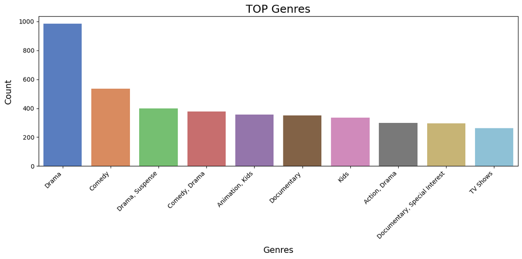

```python
# SEABORN
# Convert the data to a DataFrame
data = pd.DataFrame(atopl, columns=['Genres', 'Count'])

# Plot
plt.figure(figsize=(12, 6))
sns.barplot(x='Genres', y='Count', data=data, palette='muted')

# Customize the plot
plt.title('TOP Genres', fontsize=18)
plt.xlabel('Genres', fontsize=14, labelpad=10)
plt.ylabel('Count', fontsize=14, labelpad=10)

# Rotate x-axis labels for better visibility
plt.xticks(rotation=45, ha='right')

plt.tight_layout()
plt.show()
```

### 4.8 **Top Ratings**

```python
# Count the occurrences of each unique content rating in the "rating" column
atr = Counter(amazon_df.rating)
```

```python
# The ten most common content ratings in the Amazon Prime dataset along with their respective counts
atopr = atr.most_common(10)
atopr
```

```
[('13+', 2117),
 ('16+', 1547),
 ('ALL', 1268),
 ('18+', 1243),
 ('R', 1010),
 ('PG-13', 393),
 ('7+', 385),
 (nan, 337),
 ('PG', 253),
 ('NR', 223)]
```

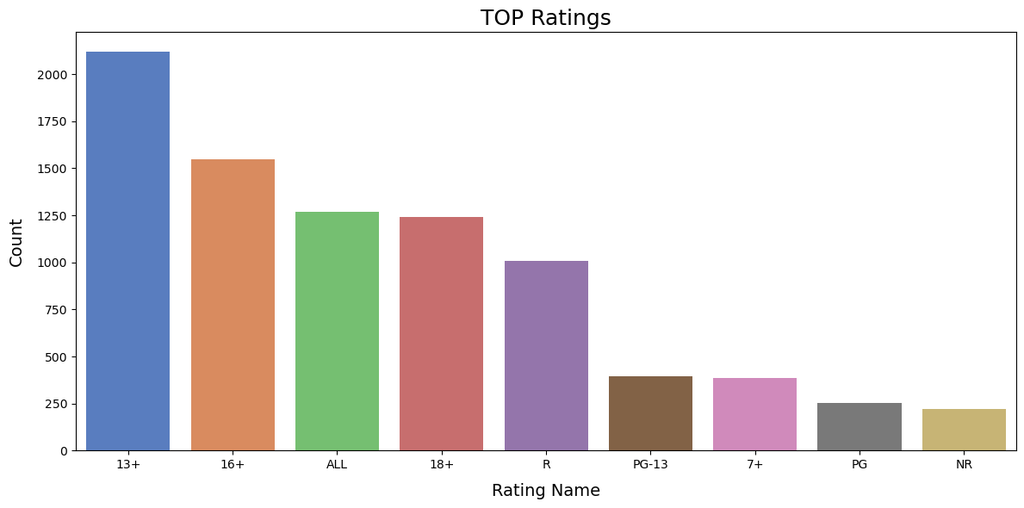

```python
# SEABORN

# Convert the data to a DataFrame
data = pd.DataFrame(atopr, columns=['Rating Name', 'Count'])

# Plot
plt.figure(figsize=(12, 6))
sns.barplot(x='Rating Name', y='Count', data=data, palette='muted')

# Customize the plot
plt.title('TOP Ratings', fontsize=18)
plt.xlabel('Rating Name', fontsize=14, labelpad=10)
plt.ylabel('Count', fontsize=14, labelpad=10)

plt.tight_layout()
plt.show()
```

## 5. Comparing Netflix & Amazon Prime

### 5.1 **Top Directors**

Create a subplot containing two bar charts, comparing the top directors between Netflix and Amazon Prime

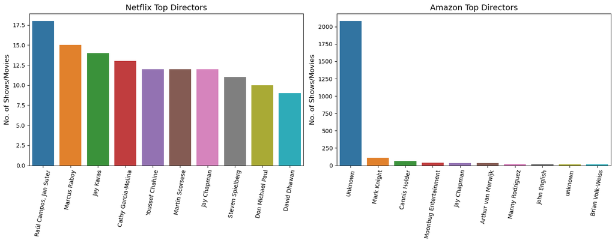

```python
# Create subplots with 1 row and 2 columns
fig, axes = plt.subplots(1, 2, figsize=(15, 6))

# Bar plot for Netflix top directors
sns.barplot(x=[i[0] for i in topdirectors],
            y=[i[1] for i in topdirectors],
            ax=axes[0])

# Bar plot for Amazon top directors
sns.barplot(x=[i[0] for i in atopdirectors],
            y=[i[1] for i in atopdirectors],
            ax=axes[1])

# Set titles for subplots
axes[0].set_title("Netflix Top Directors", fontsize=14)
axes[1].set_title("Amazon Top Directors", fontsize=14)

# Rotate x-axis labels for better readability
axes[0].tick_params(axis='x', rotation=80)
axes[1].tick_params(axis='x', rotation=80)

# Set y-axis label for both subplots
for ax in axes:
    ax.set_ylabel("No. of Shows/Movies", fontsize=12)

plt.tight_layout()
plt.show()
```

### 5.2 **Top Countries**

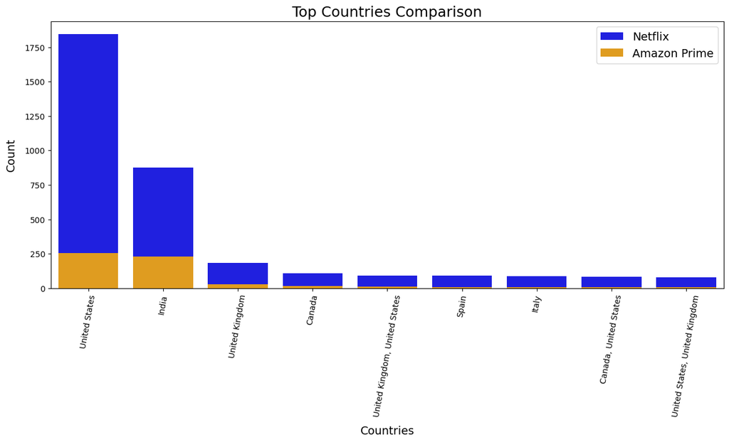

```python
# Create the subplots using Matplotlib
fig, ax = plt.subplots(figsize=(15, 6))

# Plot the top countries for Netflix
sns.barplot(x=[i[0] for i in topcountries], y=[i[1] for i in topcountries], color='blue', ax=ax, label='Netflix')

# Plot the top countries for Amazon Prime
sns.barplot(x=[i[0] for i in atopcountry], y=[i[1] for i in atopcountry], color='orange', ax=ax, label='Amazon Prime')

# Set the title and labels
ax.set_title('Top Countries Comparison', fontsize=18)
ax.set_xlabel('Countries', fontsize=14, labelpad=10)
ax.set_ylabel('Count', fontsize=14, labelpad=10)

# Rotate the x-axis labels at 80 degrees
plt.xticks(rotation=80)

# Add the legend
ax.legend(fontsize=14)

# Show the plot
plt.show()
```

### 5.3 **Top Cast Comparision**

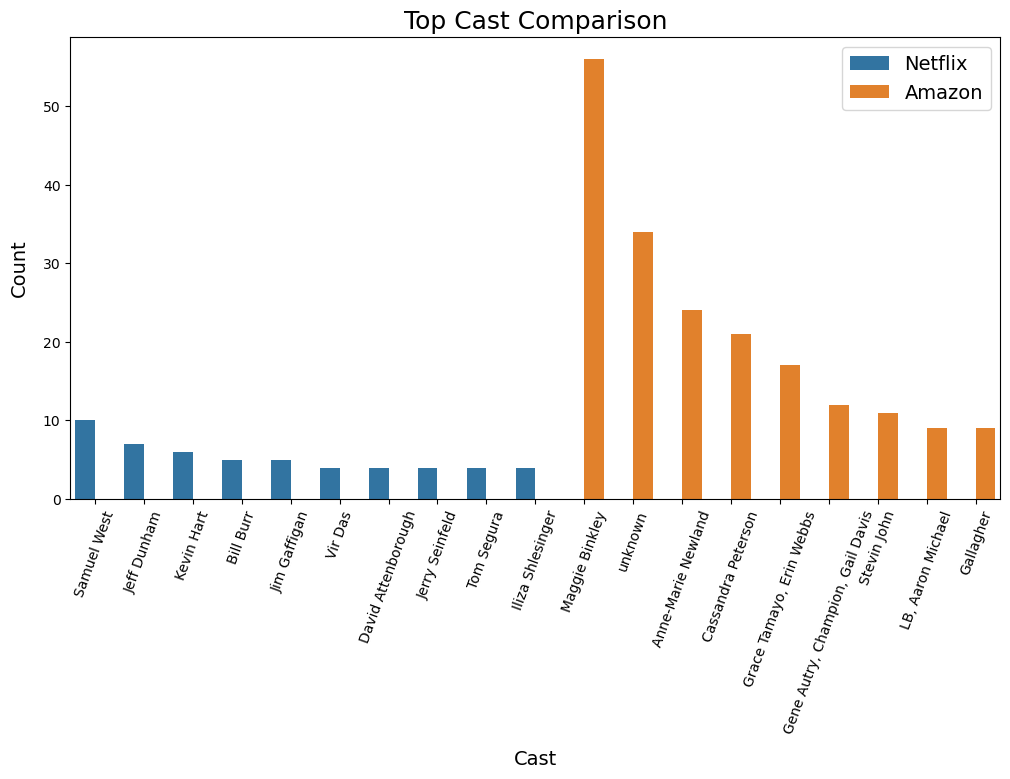

```python
# Combine the data from both platforms into a single DataFrame
topcasts_combined = topcasts + atopcast
platforms = ['Netflix'] * len(topcasts) + ['Amazon'] * len(atopcast)

# Create a DataFrame with the combined data
data = pd.DataFrame({'Cast': [i[0] for i in topcasts_combined], 'Count': [i[1] for i in topcasts_combined], 'Platform': platforms})

# Create the bar plot using seaborn
plt.figure(figsize=(12, 6))
sns.barplot(data=data, x='Cast', y='Count', hue='Platform')

# Rotate the x-axis labels at 45 degrees
plt.xticks(rotation=70)

# Set the title and labels
plt.title('Top Cast Comparison', fontsize=18)
plt.xlabel('Cast', fontsize=14, labelpad=10)
plt.ylabel('Count', fontsize=14, labelpad=10)
plt.legend(fontsize=14)

# Show the plot
plt.show()
```

### 5.4 **Top Years**

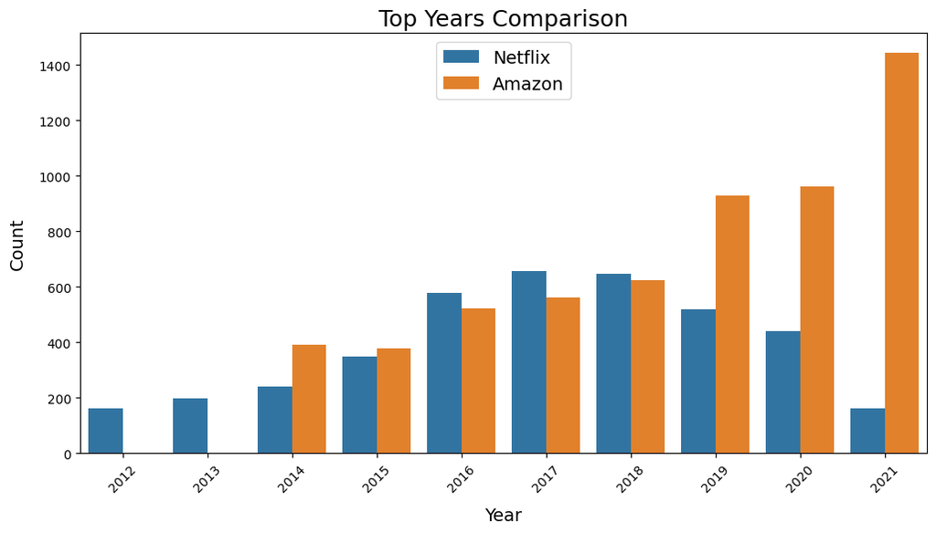

```python
# Combine the data from both platforms into a single DataFrame
top_years_combined = topry + toprya
platforms = ['Netflix'] * len(topry) + ['Amazon'] * len(toprya)

# Create a DataFrame with the combined data
data = pd.DataFrame({'Year': [i[0] for i in top_years_combined], 'Count': [i[1] for i in top_years_combined], 'Platform': platforms})

# Create the bar plot using seaborn
plt.figure(figsize=(12, 6))
sns.barplot(data=data, x='Year', y='Count', hue='Platform')

# Rotate the x-axis labels at 45 degrees
plt.xticks(rotation=45)

# Set the title and labels
plt.title('Top Years Comparison', fontsize=18)
plt.xlabel('Year', fontsize=14, labelpad=10)
plt.ylabel('Count', fontsize=14, labelpad=10)
plt.legend(fontsize=14)

# Show the plot
plt.show()
```